# Project 3

Alex Zhong

2023-10-22

## Setup

```r
# load needed packages
library(tidyverse)
library(tidytuesdayR)
library(here)
library(tidytext)
library(wordcloud)
```

```r
if (!file.exists(here("data", "b_lyrics.RDS"))) {
    b_lyrics <- readr::read_csv("https://raw.githubusercontent.com/rfordatascience/tidytuesday/master/data/2020/2020-09-29/beyonce_lyrics.csv")
    ts_lyrics <- readr::read_csv("https://raw.githubusercontent.com/rfordatascience/tidytuesday/master/data/2020/2020-09-29/taylor_swift_lyrics.csv")
    sales <- readr::read_csv("https://raw.githubusercontent.com/rfordatascience/tidytuesday/master/data/2020/2020-09-29/sales.csv")

    # save the files to RDS objects
    saveRDS(b_lyrics, file = here("data", "b_lyrics.RDS"))
    saveRDS(ts_lyrics, file = here("data", "ts_lyrics.RDS"))
    saveRDS(sales, file = here("data", "sales.RDS"))
}

b_lyrics <- readRDS(here("data", "b_lyrics.RDS"))
ts_lyrics <- readRDS(here("data", "ts_lyrics.RDS"))
raw_sales <- readRDS(here("data", "sales.RDS"))
```

## Part 1

### 1A

Taking a look at the `released` column, it seems that some of the release dates have some extra unnecessary information in the format (US/UK)[##].

```r
glimpse(raw_sales$released)
```

```
##  chr [1:48] "October 24, 2006" "November 11, 2008" "November 11, 2008" ...
```

This can be generalized as anything between the start parentheses and end bracket: (….]. To remove this, we use a regular expression, then transform it into the date format:

```r
sales <- raw_sales %>%
  mutate(released = str_remove_all(released, " \\(.*\\]") %>%
                    mdy(.))

# we can also use the more specific regex " \\(\\w{2}\\)\\[\\d{2}\\]"
```

Next, to make `country` a factor:

```r
sales <- sales %>%
  mutate(country = factor(country) %>%
                   fct_recode(., "WW" = "World", "FR" = "FRA"))

levels(sales$country)
```

```
## [1] "AUS" "CAN" "FR"  "JPN" "UK"  "US"  "WW"
```

Next, to transform `sales` into units of millions of dollars:

```r
sales <- sales %>% mutate(sales = sales / 1e6L)
```

and finally, only keeping album sales from the UK, US, or the world:

```r
sales <- sales %>%
  filter(country %in% c("US", "UK", "WW"))

sales
```

```
## # A tibble: 36 × 8
##    artist       title        country  sales released   re_release  label formats
##    <chr>        <chr>        <fct>    <dbl> <date>     <chr>       <chr> <chr>
##  1 Taylor Swift Taylor Swift US       5.72  2006-10-24 March 18, … Big … CD, CD…
##  2 Taylor Swift Fearless     WW      12     2008-11-11 October 27… Big … CD, CD…
##  3 Taylor Swift Fearless     US       7.18  2008-11-11 October 27… Big … CD, CD…
##  4 Taylor Swift Fearless     UK       0.609 2008-11-11 October 27… Big … CD, CD…
##  5 Taylor Swift Speak Now    WW       5     2010-10-25 <NA>        Big … CD, CD…
##  6 Taylor Swift Speak Now    US       4.69  2010-10-25 <NA>        Big … CD, CD…
##  7 Taylor Swift Speak Now    UK       0.169 2010-10-25 <NA>        Big … CD, CD…
##  8 Taylor Swift Red          WW       6     2012-10-22 <NA>        Big … CD, CD…
##  9 Taylor Swift Red          US       4.46  2012-10-22 <NA>        Big … CD, CD…
## 10 Taylor Swift Red          UK       0.693 2012-10-22 <NA>        Big … CD, CD…
## # ℹ 26 more rows
```

### 1B

Next, let’s look at the newest and oldest albums, as well as the median time between album releases.

```r
sales %>%
  filter(country == "US") %>%
  group_by(artist) %>%
  mutate(
    years_since_release = interval(lag(released), released) %>%
                          as.duration(.) %>%
                          as.numeric(., "years") %>%
                          floor()
  ) %>%
  summarize(
    oldest = year(min(released)),
    most_recent = year(max(released)),
    med_years_since_release = median(years_since_release, na.rm = TRUE)
  )
```

```
## # A tibble: 2 × 4
##   artist       oldest most_recent med_years_since_release
##   <chr>         <dbl>       <dbl>                   <dbl>
## 1 Beyoncé        2003        2016                     2
## 2 Taylor Swift   2006        2019                     1.5
```

Beyonce’s oldest album was released in 2003, and her newest album was released in 2016. Her median time between album releases is 2 years.

Taylor Swift’s oldest album was released in 2006 and her newest album was released in 2019. Her median time between album releases in 1.5 years.

### 1C

To compare each artist’s breakdown in sales by market, let’s make a percent stacked barchart.

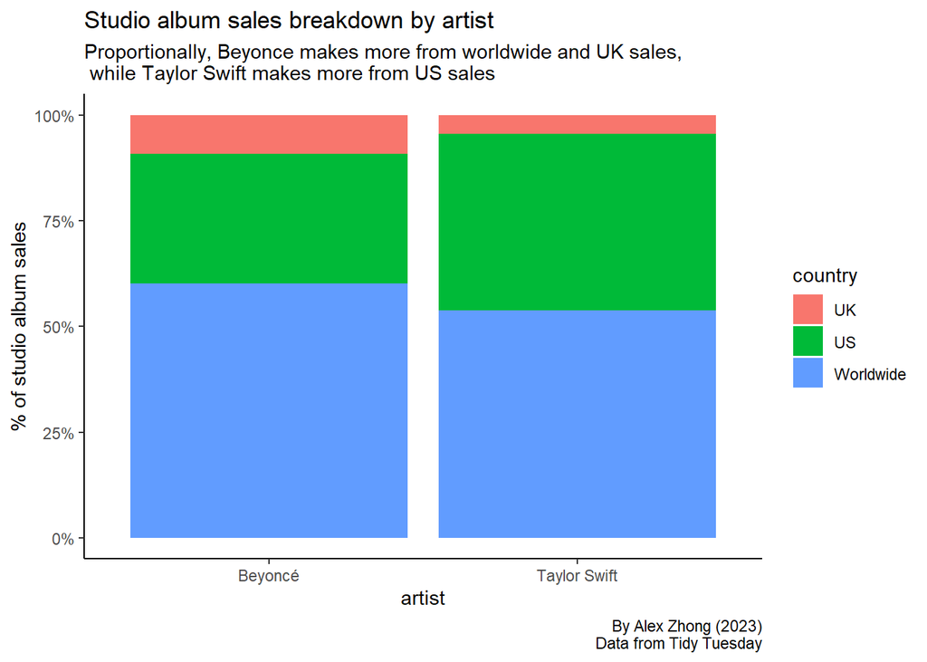

```r
sales %>%
  group_by(artist, country) %>%
  summarize(total_sales = sum(sales)) %>%
  ggplot(aes(x = artist, y = total_sales, fill = country)) +
  geom_bar(position = "fill", stat = "identity") +
  scale_y_continuous(labels = scales::percent) +
  scale_fill_discrete(labels = c("UK", "US", "Worldwide")) +
  theme_classic() +
  labs(
    title = "Studio album sales breakdown by artist",
    subtitle = "Proportionally, Beyonce makes more from worldwide and UK sales, \n while Taylor Swift makes more from US sales",
    y = "% of studio album sales",
    caption = "By Alex Zhong (2023)\n Data from Tidy Tuesday"
  )
```

### 1D

It seems that the worldwide market makes up a sizeable chunk of sales for both artists. Let’s now compare worldwide sales between Beyonce and Taylor Swift by album.

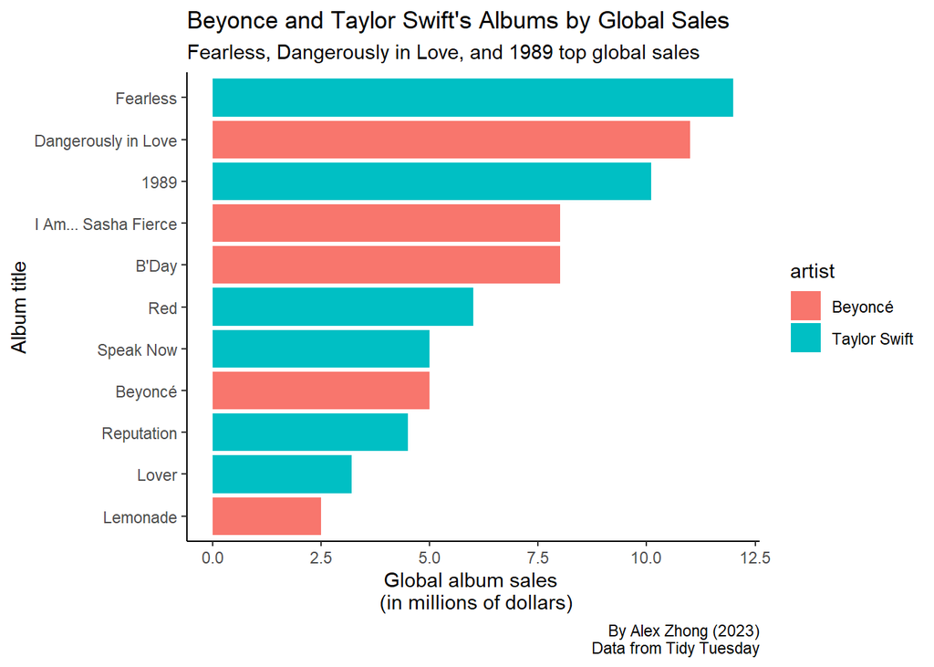

```r
sales %>%
  filter(country == "WW") %>%
  mutate(title = fct_reorder(title, sales)) %>%
  ggplot(aes(x = sales, y = title, fill = artist)) +
  geom_bar(stat = "identity") +
  theme_classic() +
  labs(
    title = "Beyonce and Taylor Swift's Albums by Global Sales",
    subtitle = "Fearless, Dangerously in Love, and 1989 top global sales",
    x = "Global album sales \n (in millions of dollars)",
    y = "Album title",
    caption = "By Alex Zhong (2023)\n Data from Tidy Tuesday"
  )
```

### 1E

Finally, let’s see how sales in all three markets for both artists change over time.

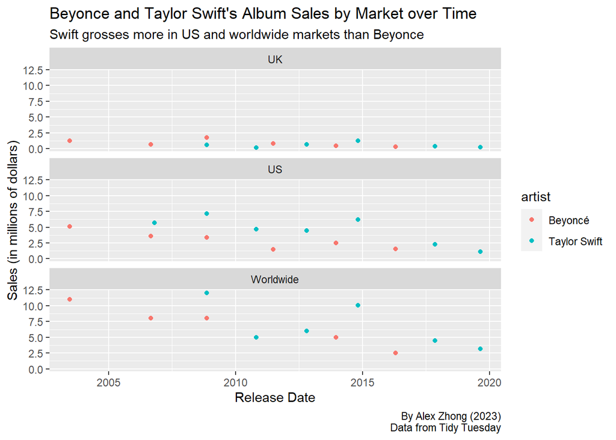

```r
country.labs = c("UK", "US", "Worldwide")
names(country.labs) = c("UK", "US", "WW")

sales %>%
  ggplot(aes(x = released, y = sales, color = artist)) +
  geom_point() +
  facet_wrap(~country, nrow = 3, labeller = labeller(country = country.labs)) +
  labs(
    title = "Beyonce and Taylor Swift's Album Sales by Market over Time",
    subtitle = "Swift grosses more in US and worldwide markets than Beyonce",
    x = "Release Date",
    y = "Sales (in millions of dollars)",
    caption = "By Alex Zhong (2023)\n Data from Tidy Tuesday"
  )
```

## Part 2

### 2A

Let’s see how many lines from Taylor Swift’s lyrics contain the words “hello” and goodbye”.

```r
count_lines_with_word = function(data, word){
  lines_data <- data %>%
    unnest_tokens(line, Lyrics, token = "lines") %>%
    filter(str_detect(line, word))

  print(paste(nrow(lines_data), "lines with the word", word))

  return(lines_data)
}

count_lines_with_word(ts_lyrics, "hello")
```

```
## [1] "6 lines with the word hello"
```

```
## # A tibble: 6 × 4
##   Artist       Album    Title                  line
##   <chr>        <chr>    <chr>                  <chr>
## 1 Taylor Swift Fearless Love Story             "and say, \"hello\""
## 2 Taylor Swift Red      I Almost Do            "that i can't say \"hello\" to y…
## 3 Taylor Swift Red      Everything Has Changed "'cause all i know is we said he…
## 4 Taylor Swift Red      Everything Has Changed "'cause all i know is we said he…
## 5 Taylor Swift Red      Everything Has Changed "all i know is we said hello"
## 6 Taylor Swift Red      Everything Has Changed "all i know is we said hello"
```

```r
count_lines_with_word(ts_lyrics, "goodbye")
```

```
## [1] "12 lines with the word goodbye"
```

```
## # A tibble: 12 × 4
##    Artist       Album        Title                      line
##    <chr>        <chr>        <chr>                      <chr>
##  1 Taylor Swift Taylor Swift Tied Together With A Smile "goodbye, baby"
##  2 Taylor Swift Speak Now    Mine                       "braced myself for the …
##  3 Taylor Swift Speak Now    Back to December           "you gave me all your l…
##  4 Taylor Swift Speak Now    Long Live                  "and force us into a go…
##  5 Taylor Swift Red          I Almost Do                "and risk another goodb…
##  6 Taylor Swift Red          Come Back Be Here          "stumbled through the l…
##  7 Taylor Swift 1989         All You Had to Do Was Stay "but people like me are…
##  8 Taylor Swift reputation   Getaway Car                "said goodbye in "
##  9 Taylor Swift reputation   Getaway Car                "said goodbye in "
## 10 Taylor Swift Lover        Death By A Thousand Cuts   "saying goodbye is deat…
## 11 Taylor Swift Lover        Death By A Thousand Cuts   "'cause saying goodbye …
## 12 Taylor Swift Lover        Daylight                   "i'll tell you truth, b…
```

### 2B

The Beyonce lyrics dataset already has individual lines separated out into rows, so we can just use `str_detect()` to count the number of lines with “hello” or “goodbye”:

```r
b_lyrics %>%
  filter(str_detect(line, "hello"))
```

```
## # A tibble: 32 × 6
##    line                        song_id song_name artist_id artist_name song_line
##    <chr>                         <dbl> <chr>         <dbl> <chr>           <dbl>
##  1 Fellow great Americans, he… 2715227 FREEDOM …       498 Beyoncé            52
##  2 You had me at hello (Hello)   80249 Hello           498 Beyoncé            15
##  3 You had me at hello (Hello)   80249 Hello           498 Beyoncé            18
##  4 'Cause you had me at hello…   80249 Hello           498 Beyoncé            24
##  5 You had me at hello (Hello)   80249 Hello           498 Beyoncé            41
##  6 You had me at hello (Hello)   80249 Hello           498 Beyoncé            44
##  7 You had me at hello (Hello)   80249 Hello           498 Beyoncé            50
##  8 Hello (Hello, hello)          80249 Hello           498 Beyoncé            52
##  9 You had me at hello (Hello)   80249 Hello           498 Beyoncé            62
## 10 You had me at hello (Hello)   80249 Hello           498 Beyoncé            65
## # ℹ 22 more rows
```

```r
b_lyrics %>%
  filter(str_detect(line, "hello")) %>%
  nrow() %>%
  paste("lines with the word 'hello'")
```

```
## [1] "32 lines with the word 'hello'"
```

```r
b_lyrics %>%
  filter(str_detect(line, "goodbye"))
```

```
## # A tibble: 12 × 6
##    line                        song_id song_name artist_id artist_name song_line
##    <chr>                         <dbl> <chr>         <dbl> <chr>           <dbl>
##  1 We only said goodbye with …  139043 Back to …       498 Beyoncé            12
##  2 We only said goodbye with …  139043 Back to …       498 Beyoncé            21
##  3 We only said goodbye with …  139043 Back to …       498 Beyoncé            24
##  4 Thank God, I found the goo…   51492 Best Thi…       498 Beyoncé            38
##  5 Thank God, I found the goo… 1946060 Best Thi…       498 Beyoncé            42
##  6 Thank God, I found the goo… 4241137 Best Thi…       498 Beyoncé            38
##  7 It's so hard to say goodbye  435491 Gift fro…       498 Beyoncé            23
##  8 I never want to say goodbye  435491 Gift fro…       498 Beyoncé            24
##  9 I never, ever want to say …  435491 Gift fro…       498 Beyoncé            25
## 10 We've got to say goodbye    1844620 Hard To …       498 Beyoncé            29
## 11 Don't have to say goodbye   1224115 Slow Love       498 Beyoncé            42
## 12 Somewhere between hi and g…  141848 Yes             498 Beyoncé            27
```

```r
b_lyrics %>%
  filter(str_detect(line, "goodbye")) %>%
  nrow() %>%
  paste("lines with the word 'goodbye'")
```

```
## [1] "12 lines with the word 'goodbye'"
```

### 2C

Now, let’s look at the sentiments of Beyonce’s top 25 most-used words in her lyrics.

```r
data(stop_words)

bing_sent <- get_sentiments("bing")

b_words <- b_lyrics %>%
  unnest_tokens(word, line, token = "words") %>%
  anti_join(stop_words) %>%
  count(word, sort = TRUE) %>%
  inner_join(bing_sent) %>%
  head(25)
b_words
```

```
## # A tibble: 25 × 3
##    word          n sentiment
##    <chr>     <int> <chr>
##  1 love       1362 positive
##  2 crazy       308 negative
##  3 top         241 positive
##  4 bad         132 negative
##  5 beautiful   131 positive
##  6 whoa        121 positive
##  7 damn        106 negative
##  8 hurt         90 negative
##  9 hard         87 negative
## 10 ready        85 positive
## # ℹ 15 more rows
```

Now, let’s create a bar plot of these top 25 words used by Beyonce:

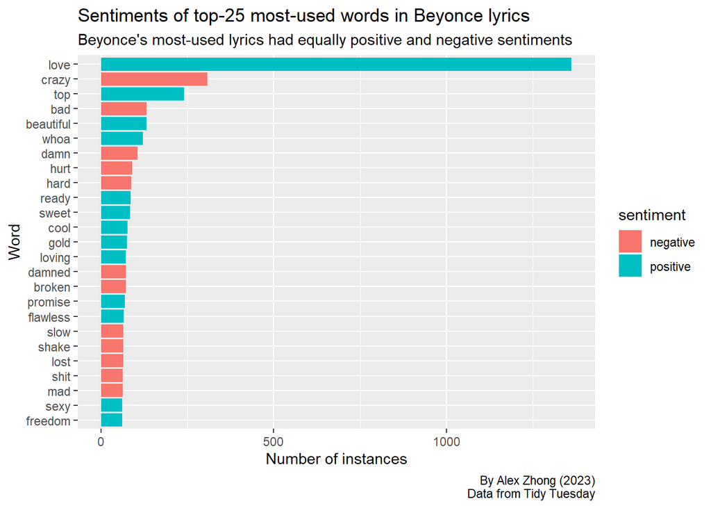

```r
b_words %>%
  mutate(word = fct_reorder(word, n)) %>%
  ggplot(aes(x = n, y = word, fill = sentiment)) +
  geom_bar(stat = "identity") +
  labs(
    title = "Sentiments of top-25 most-used words in Beyonce lyrics",
    subtitle = "Beyonce's most-used lyrics had equally positive and negative sentiments",
    x = "Number of instances",
    y = "Word",
    caption = "By Alex Zhong (2023)\n Data from Tidy Tuesday"
  )
```

And a word cloud:

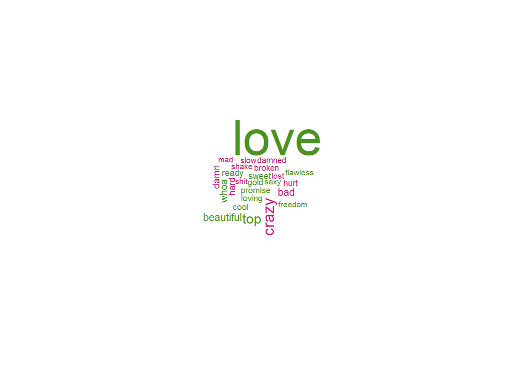

```r
b_words %>%
  mutate(
    color = case_when(
      sentiment == "negative" ~ "#c51b7d",
      sentiment == "positive" ~ "#4d9221"
    )
  ) %>%
  with(wordcloud(word, n, colors = color, ordered.colors = TRUE))
```

### 2D

Now, let’s perform the same analysis with Taylor Swift’s lyrics:

```r
ts_words <- ts_lyrics %>%
  unnest_tokens(word, Lyrics, token = "words") %>%
  anti_join(stop_words) %>%
  count(word, sort = TRUE) %>%
  inner_join(bing_sent) %>%
  head(25)
ts_words
```

```
## # A tibble: 25 × 3
##    word          n sentiment
##    <chr>     <int> <chr>
##  1 love        248 positive
##  2 bad          80 negative
##  3 shake        73 negative
##  4 break        59 negative
##  5 mad          48 negative
##  6 beautiful    46 positive
##  7 smile        45 positive
##  8 hate         44 negative
##  9 fall         43 negative
## 10 whoa         36 positive
## # ℹ 15 more rows
```

Plotting these words in a bar plot,

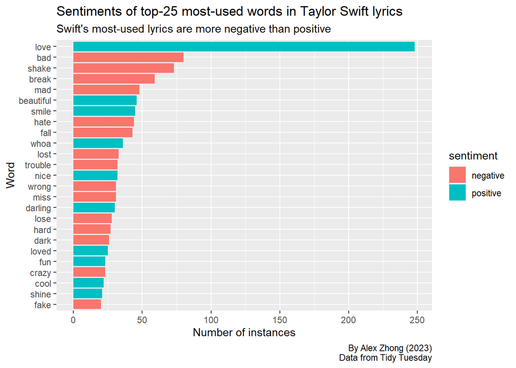

```r
ts_words %>%
  mutate(word = fct_reorder(word, n)) %>%
  ggplot(aes(x = n, y = word, fill = sentiment)) +
  geom_bar(stat = "identity") +
  labs(
    title = "Sentiments of top-25 most-used words in Taylor Swift lyrics",
    subtitle = "Swift's most-used lyrics are more negative than positive",
    x = "Number of instances",
    y = "Word",
    caption = "By Alex Zhong (2023)\n Data from Tidy Tuesday"
  )
```

And a word cloud:

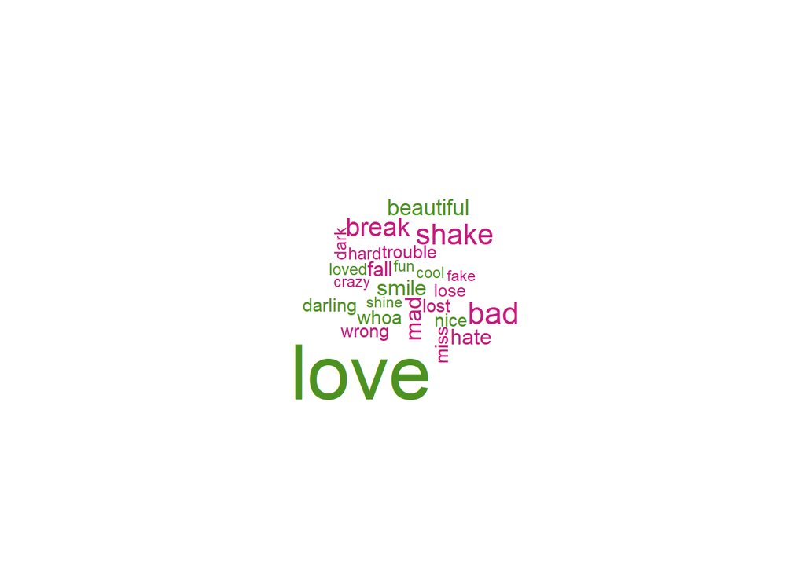

```r
ts_words %>%
  mutate(
    color = case_when(
      sentiment == "negative" ~ "#c51b7d",
      sentiment == "positive" ~ "#4d9221"
    )
  ) %>%
  with(wordcloud(word, n, colors = color, ordered.colors = TRUE))
```

### 2E

Using the “afinn” lexicon, let’s calculate the average sentiment for Taylor Swift’s albums.

```r
ts_avgsent <- ts_lyrics %>%
  unnest_tokens(word, Lyrics, token = "words") %>%
  anti_join(stop_words) %>%
  group_by(Album) %>%
  count(word) %>%
  inner_join(get_sentiments("afinn")) %>%
  summarize(
    avg_sentiment = sum(n * value) / sum(n)
  )
ts_avgsent
```

```
## # A tibble: 8 × 2
##   Album        avg_sentiment
##   <chr>                <dbl>
## 1 1989               -0.215
## 2 Fearless            0.452
## 3 Lover               0.0960
## 4 Red                 0.256
## 5 Speak Now           0.0219
## 6 Taylor Swift        0.646
## 7 folklore           -0.396
## 8 reputation          0.0501
```

Next, we’ll join this average sentiment data with sales and release date data:

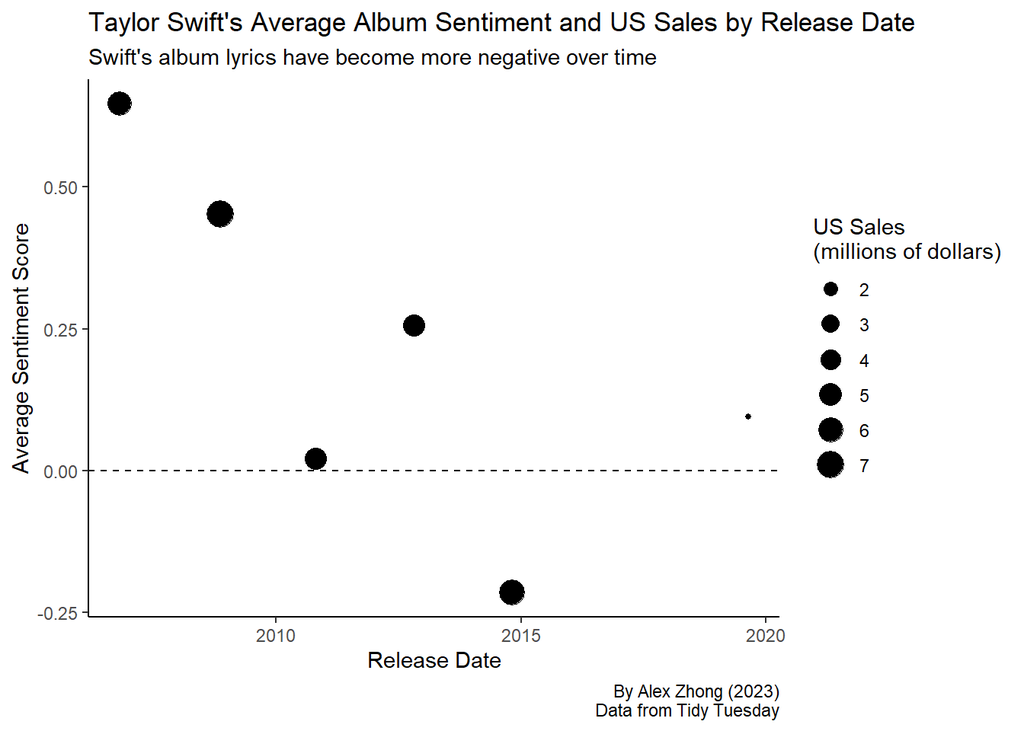

```r
sales %>%
  filter(country == "US") %>%
  select(title, sales, released) %>%
  inner_join(ts_avgsent, by = join_by(title == Album)) %>%
  ggplot(aes(x = released, y = avg_sentiment, size = sales)) +
  geom_point() +
  geom_hline(aes(yintercept = 0), linetype = "dashed") +
  labs(
    title = "Taylor Swift's Average Album Sentiment and US Sales by Release Date",
    subtitle = "Swift's album lyrics have become more negative over time",
    x = "Release Date",
    y = "Average Sentiment Score",
    size = "US Sales \n(millions of dollars)",
    caption = "By Alex Zhong (2023)\n Data from Tidy Tuesday"
  ) +
  theme_classic()
```

## R Session Info

```r
options(width = 120)
```